# Risk Factor Analysis

## Outcome Variable

**Outcome Variable:** ever_stunted

## Predictor Variables

**Intervention Variable:** feducyrs

**Adjustment Set:**

- arm
- W_mage
- meducyrs
- hhwealth_quart
- W_mhtcm
- W_gagebrth
- W_birthwt
- W_birthlen
- W_nrooms
- W_nchldlt5
- impfloor
- impsan
- safeh20
- delta_W_mage
- delta_meducyrs
- delta_hhwealth_quart
- delta_W_mhtcm
- delta_W_gagebrth
- delta_W_birthwt
- delta_W_birthlen
- delta_W_nrooms
- delta_W_nchldlt5
- delta_impfloor
- delta_impsan
- delta_safeh20

## Stratifying Variables

The analysis was stratified on these variable(s):

- agecat
- studyid
- country

## Data Summary

| agecat | studyid | country | feducyrs | ever_stunted | n_cell | n |
| --- | --- | --- | --- | --- | --- | --- |
| 0-24 months | ki0047075b-MAL-ED | BANGLADESH | Low | 0 | 15 | 149 |
| 0-24 months | ki0047075b-MAL-ED | BANGLADESH | Low | 1 | 25 | 149 |
| 0-24 months | ki0047075b-MAL-ED | BANGLADESH | Medium | 0 | 20 | 149 |
| 0-24 months | ki0047075b-MAL-ED | BANGLADESH | Medium | 1 | 35 | 149 |
| 0-24 months | ki0047075b-MAL-ED | BANGLADESH | High | 0 | 31 | 149 |
| 0-24 months | ki0047075b-MAL-ED | BANGLADESH | High | 1 | 23 | 149 |
| 0-24 months | ki0047075b-MAL-ED | INDIA | Low | 0 | 28 | 147 |
| 0-24 months | ki0047075b-MAL-ED | INDIA | Low | 1 | 31 | 147 |
| 0-24 months | ki0047075b-MAL-ED | INDIA | Medium | 0 | 18 | 147 |
| 0-24 months | ki0047075b-MAL-ED | INDIA | Medium | 1 | 26 | 147 |
| 0-24 months | ki0047075b-MAL-ED | INDIA | High | 0 | 18 | 147 |
| 0-24 months | ki0047075b-MAL-ED | INDIA | High | 1 | 26 | 147 |
| 0-24 months | ki0047075b-MAL-ED | NEPAL | Low | 0 | 16 | 98 |
| 0-24 months | ki0047075b-MAL-ED | NEPAL | Low | 1 | 12 | 98 |
| 0-24 months | ki0047075b-MAL-ED | NEPAL | Medium | 0 | 15 | 98 |
| 0-24 months | ki0047075b-MAL-ED | NEPAL | Medium | 1 | 13 | 98 |
| 0-24 months | ki0047075b-MAL-ED | NEPAL | High | 0 | 32 | 98 |
| 0-24 months | ki0047075b-MAL-ED | NEPAL | High | 1 | 10 | 98 |
| 0-24 months | ki0047075b-MAL-ED | PERU | Low | 0 | 28 | 250 |
| 0-24 months | ki0047075b-MAL-ED | PERU | Low | 1 | 41 | 250 |
| 0-24 months | ki0047075b-MAL-ED | PERU | Medium | 0 | 20 | 250 |
| 0-24 months | ki0047075b-MAL-ED | PERU | Medium | 1 | 41 | 250 |
| 0-24 months | ki0047075b-MAL-ED | PERU | High | 0 | 45 | 250 |
| 0-24 months | ki0047075b-MAL-ED | PERU | High | 1 | 75 | 250 |
| 0-24 months | ki0047075b-MAL-ED | SOUTH AFRICA | Low | 0 | 18 | 110 |
| 0-24 months | ki0047075b-MAL-ED | SOUTH AFRICA | Low | 1 | 19 | 110 |
| 0-24 months | ki0047075b-MAL-ED | SOUTH AFRICA | Medium | 0 | 11 | 110 |
| 0-24 months | ki0047075b-MAL-ED | SOUTH AFRICA | Medium | 1 | 19 | 110 |
| 0-24 months | ki0047075b-MAL-ED | SOUTH AFRICA | High | 0 | 15 | 110 |
| 0-24 months | ki0047075b-MAL-ED | SOUTH AFRICA | High | 1 | 28 | 110 |

[output cut: 330 more lines]

The following strata were considered:

- agecat: 0-24 months, studyid: ki0047075b-MAL-ED, country: BANGLADESH
- agecat: 0-24 months, studyid: ki0047075b-MAL-ED, country: INDIA
- agecat: 0-24 months, studyid: ki0047075b-MAL-ED, country: NEPAL
- agecat: 0-24 months, studyid: ki0047075b-MAL-ED, country: PERU
- agecat: 0-24 months, studyid: ki0047075b-MAL-ED, country: SOUTH AFRICA
- agecat: 0-24 months, studyid: ki0047075b-MAL-ED, country: TANZANIA, UNITED REPUBLIC OF
- agecat: 0-24 months, studyid: ki1000304b-SAS-CompFeed, country: INDIA
- agecat: 0-24 months, studyid: ki1000304b-SAS-FoodSuppl, country: INDIA
- agecat: 0-24 months, studyid: ki1017093b-PROVIDE, country: BANGLADESH
- agecat: 0-24 months, studyid: ki1017093c-NIH-Crypto, country: BANGLADESH
- agecat: 0-24 months, studyid: ki1066203-TanzaniaChild2, country: TANZANIA, UNITED REPUBLIC OF
- agecat: 0-24 months, studyid: ki1113344-GMS-Nepal, country: NEPAL
- agecat: 0-24 months, studyid: ki1119695-PROBIT, country: BELARUS
- agecat: 0-24 months, studyid: ki1126311-ZVITAMBO, country: ZIMBABWE
- agecat: 0-24 months, studyid: ki1135781-COHORTS, country: GUATEMALA
- agecat: 0-24 months, studyid: ki1135781-COHORTS, country: INDIA
- agecat: 0-24 months, studyid: ki1135781-COHORTS, country: PHILIPPINES
- agecat: 0-24 months, studyid: ki1148112-LCNI-5, country: MALAWI
- agecat: 0-24 months, studyid: kiGH5241-JiVitA-3, country: BANGLADESH
- agecat: 0-24 months, studyid: kiGH5241-JiVitA-4, country: BANGLADESH
- agecat: 0-6 months, studyid: ki0047075b-MAL-ED, country: BANGLADESH
- agecat: 0-6 months, studyid: ki0047075b-MAL-ED, country: INDIA
- agecat: 0-6 months, studyid: ki0047075b-MAL-ED, country: NEPAL
- agecat: 0-6 months, studyid: ki0047075b-MAL-ED, country: PERU
- agecat: 0-6 months, studyid: ki0047075b-MAL-ED, country: SOUTH AFRICA
- agecat: 0-6 months, studyid: ki0047075b-MAL-ED, country: TANZANIA, UNITED REPUBLIC OF
- agecat: 0-6 months, studyid: ki1000304b-SAS-CompFeed, country: INDIA
- agecat: 0-6 months, studyid: ki1000304b-SAS-FoodSuppl, country: INDIA
- agecat: 0-6 months, studyid: ki1017093b-PROVIDE, country: BANGLADESH
- agecat: 0-6 months, studyid: ki1017093c-NIH-Crypto, country: BANGLADESH
- agecat: 0-6 months, studyid: ki1066203-TanzaniaChild2, country: TANZANIA, UNITED REPUBLIC OF
- agecat: 0-6 months, studyid: ki1113344-GMS-Nepal, country: NEPAL
- agecat: 0-6 months, studyid: ki1119695-PROBIT, country: BELARUS
- agecat: 0-6 months, studyid: ki1126311-ZVITAMBO, country: ZIMBABWE
- agecat: 0-6 months, studyid: ki1135781-COHORTS, country: GUATEMALA
- agecat: 0-6 months, studyid: ki1135781-COHORTS, country: INDIA
- agecat: 0-6 months, studyid: ki1135781-COHORTS, country: PHILIPPINES
- agecat: 0-6 months, studyid: ki1148112-LCNI-5, country: MALAWI
- agecat: 0-6 months, studyid: kiGH5241-JiVitA-3, country: BANGLADESH
- agecat: 0-6 months, studyid: kiGH5241-JiVitA-4, country: BANGLADESH
- agecat: 6-24 months, studyid: ki0047075b-MAL-ED, country: BANGLADESH
- agecat: 6-24 months, studyid: ki0047075b-MAL-ED, country: INDIA
- agecat: 6-24 months, studyid: ki0047075b-MAL-ED, country: NEPAL
- agecat: 6-24 months, studyid: ki0047075b-MAL-ED, country: PERU
- agecat: 6-24 months, studyid: ki0047075b-MAL-ED, country: SOUTH AFRICA
- agecat: 6-24 months, studyid: ki0047075b-MAL-ED, country: TANZANIA, UNITED REPUBLIC OF
- agecat: 6-24 months, studyid: ki1000304b-SAS-CompFeed, country: INDIA
- agecat: 6-24 months, studyid: ki1000304b-SAS-FoodSuppl, country: INDIA
- agecat: 6-24 months, studyid: ki1017093b-PROVIDE, country: BANGLADESH
- agecat: 6-24 months, studyid: ki1017093c-NIH-Crypto, country: BANGLADESH
- agecat: 6-24 months, studyid: ki1066203-TanzaniaChild2, country: TANZANIA, UNITED REPUBLIC OF
- agecat: 6-24 months, studyid: ki1113344-GMS-Nepal, country: NEPAL
- agecat: 6-24 months, studyid: ki1119695-PROBIT, country: BELARUS
- agecat: 6-24 months, studyid: ki1126311-ZVITAMBO, country: ZIMBABWE
- agecat: 6-24 months, studyid: ki1135781-COHORTS, country: GUATEMALA
- agecat: 6-24 months, studyid: ki1135781-COHORTS, country: INDIA
- agecat: 6-24 months, studyid: ki1135781-COHORTS, country: PHILIPPINES
- agecat: 6-24 months, studyid: ki1148112-LCNI-5, country: MALAWI
- agecat: 6-24 months, studyid: kiGH5241-JiVitA-3, country: BANGLADESH
- agecat: 6-24 months, studyid: kiGH5241-JiVitA-4, country: BANGLADESH

### Dropped Strata

Some strata were dropped due to rare outcomes:

- agecat: 0-24 months, studyid: ki0047075b-MAL-ED, country: TANZANIA, UNITED REPUBLIC OF
- agecat: 0-6 months, studyid: ki0047075b-MAL-ED, country: NEPAL
- agecat: 6-24 months, studyid: ki0047075b-MAL-ED, country: NEPAL
- agecat: 6-24 months, studyid: ki0047075b-MAL-ED, country: TANZANIA, UNITED REPUBLIC OF

## Methods Detail

We’re interested in the causal parameters $E[Y_a]$ for all values of $a \in \mathcal{A}$. These parameters represent the mean outcome if, possibly contrary to fact, we intervened to set all units to have $A=a$. Under the randomization and positivity assumptions, these are identified by the statistical parameters $\psi_a=E_W[E_{Y|A,W}(Y|A=a,W)]$. In addition, we’re interested in the mean of $Y$, $E[Y]$ under no intervention (the observed mean). We will estimate these parameters by using SuperLearner to fit the relevant likelihood factors – $E_{Y|A,W}(Y|A=a,W)$ and $p(A=a|W)$, and then updating our likelihood fit using a joint TMLE.

For unadjusted analyses ($W=\{\}$), initial likelihoods were estimated using Lrnr_glm to estimate the simple $E(Y|A)$ and Lrnr_mean to estimate $p(A)$. For adjusted analyses, a small library containing Lrnr_glmnet, Lrnr_xgboost, and Lrnr_mean was used.

Having estimated these parameters, we will then use the delta method to estimate relative risks and attributable risks relative to a prespecified baseline level of $A$.

# Results Detail

## Results Plots

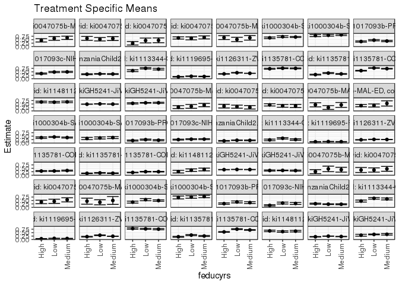

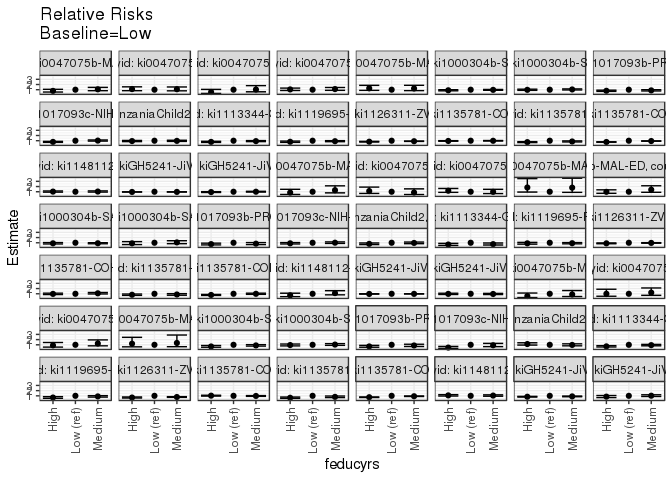

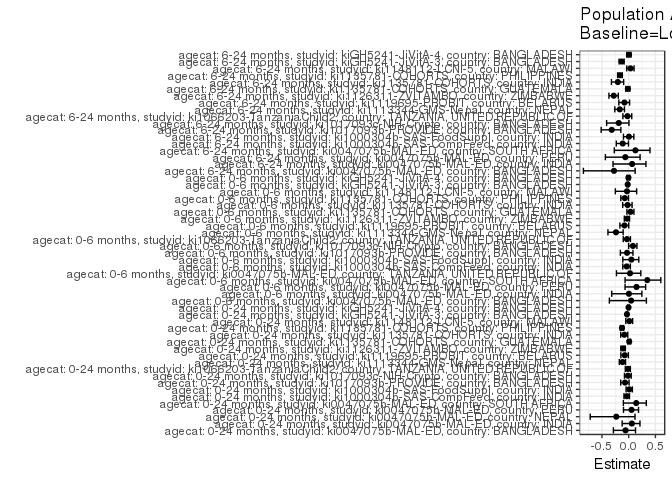

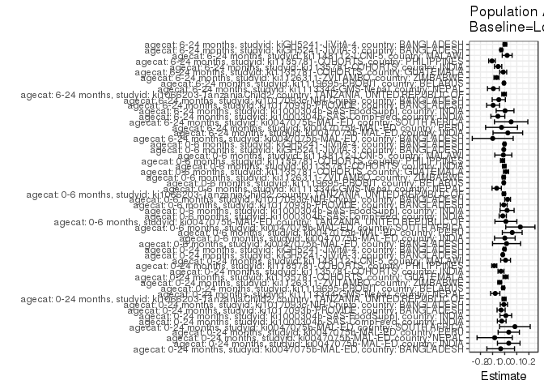

## Results Table

### Parameter: TSM

| agecat | studyid | country | intervention_level | baseline_level | estimate | ci_lower | ci_upper |
| --- | --- | --- | --- | --- | --- | --- | --- |
| 0-24 months | ki0047075b-MAL-ED | BANGLADESH | Low | NA | 0.5900265 | 0.4532897 | 0.7267633 |
| 0-24 months | ki0047075b-MAL-ED | BANGLADESH | Medium | NA | 0.6347894 | 0.5146696 | 0.7549091 |
| 0-24 months | ki0047075b-MAL-ED | BANGLADESH | High | NA | 0.4528694 | 0.3325735 | 0.5731653 |
| 0-24 months | ki0047075b-MAL-ED | INDIA | Low | NA | 0.5312276 | 0.4081102 | 0.6543451 |
| 0-24 months | ki0047075b-MAL-ED | INDIA | Medium | NA | 0.5800500 | 0.4376703 | 0.7224296 |
| 0-24 months | ki0047075b-MAL-ED | INDIA | High | NA | 0.5938830 | 0.4521705 | 0.7355955 |
| 0-24 months | ki0047075b-MAL-ED | NEPAL | Low | NA | 0.4398330 | 0.2633406 | 0.6163254 |
| 0-24 months | ki0047075b-MAL-ED | NEPAL | Medium | NA | 0.4530499 | 0.2792314 | 0.6268684 |
| 0-24 months | ki0047075b-MAL-ED | NEPAL | High | NA | 0.2404054 | 0.1141554 | 0.3666555 |
| 0-24 months | ki0047075b-MAL-ED | PERU | Low | NA | 0.5943724 | 0.4870142 | 0.7017307 |
| 0-24 months | ki0047075b-MAL-ED | PERU | Medium | NA | 0.6637678 | 0.5532614 | 0.7742741 |
| 0-24 months | ki0047075b-MAL-ED | PERU | High | NA | 0.6261785 | 0.5457937 | 0.7065633 |
| 0-24 months | ki0047075b-MAL-ED | SOUTH AFRICA | Low | NA | 0.5154458 | 0.3585242 | 0.6723674 |
| 0-24 months | ki0047075b-MAL-ED | SOUTH AFRICA | Medium | NA | 0.6355066 | 0.4675542 | 0.8034590 |
| 0-24 months | ki0047075b-MAL-ED | SOUTH AFRICA | High | NA | 0.6521968 | 0.5111215 | 0.7932722 |
| 0-24 months | ki1000304b-SAS-CompFeed | INDIA | Low | NA | 0.7153133 | 0.6514955 | 0.7791310 |
| 0-24 months | ki1000304b-SAS-CompFeed | INDIA | Medium | NA | 0.6920569 | 0.6520376 | 0.7320761 |
| 0-24 months | ki1000304b-SAS-CompFeed | INDIA | High | NA | 0.6345513 | 0.5781164 | 0.6909863 |
| 0-24 months | ki1000304b-SAS-FoodSuppl | INDIA | Low | NA | 0.8182446 | 0.7574214 | 0.8790679 |
| 0-24 months | ki1000304b-SAS-FoodSuppl | INDIA | Medium | NA | 0.8556234 | 0.8013693 | 0.9098775 |
| 0-24 months | ki1000304b-SAS-FoodSuppl | INDIA | High | NA | 0.7981825 | 0.7252935 | 0.8710716 |
| 0-24 months | ki1017093b-PROVIDE | BANGLADESH | Low | NA | 0.4638017 | 0.4169020 | 0.5107015 |
| 0-24 months | ki1017093b-PROVIDE | BANGLADESH | Medium | NA | 0.4015279 | 0.3541525 | 0.4489032 |
| 0-24 months | ki1017093b-PROVIDE | BANGLADESH | High | NA | 0.3651797 | 0.3208660 | 0.4094934 |
| 0-24 months | ki1017093c-NIH-Crypto | BANGLADESH | Low | NA | 0.4842353 | 0.4419195 | 0.5265511 |
| 0-24 months | ki1017093c-NIH-Crypto | BANGLADESH | Medium | NA | 0.4961939 | 0.4538498 | 0.5385381 |
| 0-24 months | ki1017093c-NIH-Crypto | BANGLADESH | High | NA | 0.3740082 | 0.3349453 | 0.4130712 |
| 0-24 months | ki1066203-TanzaniaChild2 | TANZANIA, UNITED REPUBLIC OF | Low | NA | 0.3517401 | 0.3270672 | 0.3764130 |
| 0-24 months | ki1066203-TanzaniaChild2 | TANZANIA, UNITED REPUBLIC OF | Medium | NA | 0.3412400 | 0.3095209 | 0.3729592 |
| 0-24 months | ki1066203-TanzaniaChild2 | TANZANIA, UNITED REPUBLIC OF | High | NA | 0.3292219 | 0.2953028 | 0.3631410 |

[output cut: 138 more lines]

### Parameter: E(Y)

| agecat | studyid | country | intervention_level | baseline_level | estimate | ci_lower | ci_upper |
| --- | --- | --- | --- | --- | --- | --- | --- |
| 0-24 months | ki0047075b-MAL-ED | BANGLADESH | NA | NA | 0.5570470 | 0.4770190 | 0.6370750 |
| 0-24 months | ki0047075b-MAL-ED | INDIA | NA | NA | 0.5646258 | 0.4842023 | 0.6450494 |
| 0-24 months | ki0047075b-MAL-ED | NEPAL | NA | NA | 0.3571429 | 0.2617885 | 0.4524972 |
| 0-24 months | ki0047075b-MAL-ED | PERU | NA | NA | 0.6280000 | 0.5679657 | 0.6880343 |
| 0-24 months | ki0047075b-MAL-ED | SOUTH AFRICA | NA | NA | 0.6000000 | 0.5080312 | 0.6919688 |
| 0-24 months | ki1000304b-SAS-CompFeed | INDIA | NA | NA | 0.6908497 | 0.6505448 | 0.7311545 |
| 0-24 months | ki1000304b-SAS-FoodSuppl | INDIA | NA | NA | 0.8277512 | 0.7915095 | 0.8639929 |
| 0-24 months | ki1017093b-PROVIDE | BANGLADESH | NA | NA | 0.4342857 | 0.3975409 | 0.4710305 |
| 0-24 months | ki1017093c-NIH-Crypto | BANGLADESH | NA | NA | 0.4775726 | 0.4419904 | 0.5131548 |
| 0-24 months | ki1066203-TanzaniaChild2 | TANZANIA, UNITED REPUBLIC OF | NA | NA | 0.3466219 | 0.3275107 | 0.3657331 |
| 0-24 months | ki1113344-GMS-Nepal | NEPAL | NA | NA | 0.6755408 | 0.6380799 | 0.7130017 |
| 0-24 months | ki1119695-PROBIT | BELARUS | NA | NA | 0.1652568 | 0.1463320 | 0.1841817 |
| 0-24 months | ki1126311-ZVITAMBO | ZIMBABWE | NA | NA | 0.3929015 | 0.3847209 | 0.4010821 |
| 0-24 months | ki1135781-COHORTS | GUATEMALA | NA | NA | 0.7672000 | 0.7437624 | 0.7906376 |
| 0-24 months | ki1135781-COHORTS | INDIA | NA | NA | 0.3780235 | 0.3530310 | 0.4030160 |
| 0-24 months | ki1135781-COHORTS | PHILIPPINES | NA | NA | 0.6899306 | 0.6730355 | 0.7068256 |
| 0-24 months | ki1148112-LCNI-5 | MALAWI | NA | NA | 0.6371464 | 0.6040748 | 0.6702180 |
| 0-24 months | kiGH5241-JiVitA-3 | BANGLADESH | NA | NA | 0.4918077 | 0.4839022 | 0.4997131 |
| 0-24 months | kiGH5241-JiVitA-4 | BANGLADESH | NA | NA | 0.5831941 | 0.5609849 | 0.6054033 |
| 0-6 months | ki0047075b-MAL-ED | BANGLADESH | NA | NA | 0.3422819 | 0.2658404 | 0.4187234 |
| 0-6 months | ki0047075b-MAL-ED | INDIA | NA | NA | 0.3061224 | 0.2313639 | 0.3808810 |
| 0-6 months | ki0047075b-MAL-ED | PERU | NA | NA | 0.4280000 | 0.3665434 | 0.4894566 |
| 0-6 months | ki0047075b-MAL-ED | SOUTH AFRICA | NA | NA | 0.3727273 | 0.2819539 | 0.4635007 |
| 0-6 months | ki0047075b-MAL-ED | TANZANIA, UNITED REPUBLIC OF | NA | NA | 0.4009434 | 0.3348159 | 0.4670709 |
| 0-6 months | ki1000304b-SAS-CompFeed | INDIA | NA | NA | 0.4250164 | 0.3969651 | 0.4530677 |
| 0-6 months | ki1000304b-SAS-FoodSuppl | INDIA | NA | NA | 0.3894231 | 0.3425088 | 0.4363374 |
| 0-6 months | ki1017093b-PROVIDE | BANGLADESH | NA | NA | 0.2385714 | 0.2069753 | 0.2701675 |
| 0-6 months | ki1017093c-NIH-Crypto | BANGLADESH | NA | NA | 0.3021108 | 0.2694011 | 0.3348205 |
| 0-6 months | ki1066203-TanzaniaChild2 | TANZANIA, UNITED REPUBLIC OF | NA | NA | 0.1951322 | 0.1792173 | 0.2110471 |
| 0-6 months | ki1113344-GMS-Nepal | NEPAL | NA | NA | 0.2778702 | 0.2420275 | 0.3137129 |
| 0-6 months | ki1119695-PROBIT | BELARUS | NA | NA | 0.0977315 | 0.0847284 | 0.1107345 |
| 0-6 months | ki1126311-ZVITAMBO | ZIMBABWE | NA | NA | 0.2559789 | 0.2486637 | 0.2632941 |
| 0-6 months | ki1135781-COHORTS | GUATEMALA | NA | NA | 0.3196078 | 0.2909760 | 0.3482397 |
| 0-6 months | ki1135781-COHORTS | INDIA | NA | NA | 0.1639690 | 0.1447117 | 0.1832264 |
| 0-6 months | ki1135781-COHORTS | PHILIPPINES | NA | NA | 0.2381944 | 0.2226342 | 0.2537546 |
| 0-6 months | ki1148112-LCNI-5 | MALAWI | NA | NA | 0.3558052 | 0.2982716 | 0.4133389 |
| 0-6 months | kiGH5241-JiVitA-3 | BANGLADESH | NA | NA | 0.4088773 | 0.4013389 | 0.4164158 |
| 0-6 months | kiGH5241-JiVitA-4 | BANGLADESH | NA | NA | 0.3464052 | 0.3252865 | 0.3675239 |
| 6-24 months | ki0047075b-MAL-ED | BANGLADESH | NA | NA | 0.3595506 | 0.2592902 | 0.4598109 |
| 6-24 months | ki0047075b-MAL-ED | INDIA | NA | NA | 0.4042553 | 0.3045164 | 0.5039942 |
| 6-24 months | ki0047075b-MAL-ED | PERU | NA | NA | 0.4132231 | 0.3251210 | 0.5013252 |
| 6-24 months | ki0047075b-MAL-ED | SOUTH AFRICA | NA | NA | 0.4237288 | 0.2965568 | 0.5509008 |
| 6-24 months | ki1000304b-SAS-CompFeed | INDIA | NA | NA | 0.5024631 | 0.4586872 | 0.5462389 |
| 6-24 months | ki1000304b-SAS-FoodSuppl | INDIA | NA | NA | 0.7572016 | 0.7031798 | 0.8112234 |
| 6-24 months | ki1017093b-PROVIDE | BANGLADESH | NA | NA | 0.2997812 | 0.2577294 | 0.3418330 |
| 6-24 months | ki1017093c-NIH-Crypto | BANGLADESH | NA | NA | 0.2628458 | 0.2244546 | 0.3012371 |
| 6-24 months | ki1066203-TanzaniaChild2 | TANZANIA, UNITED REPUBLIC OF | NA | NA | 0.2263323 | 0.2057897 | 0.2468748 |
| 6-24 months | ki1113344-GMS-Nepal | NEPAL | NA | NA | 0.5623529 | 0.5151323 | 0.6095736 |
| 6-24 months | ki1119695-PROBIT | BELARUS | NA | NA | 0.0761786 | 0.0621943 | 0.0901630 |
| 6-24 months | ki1126311-ZVITAMBO | ZIMBABWE | NA | NA | 0.2426433 | 0.2330974 | 0.2521891 |
| 6-24 months | ki1135781-COHORTS | GUATEMALA | NA | NA | 0.7617329 | 0.7327499 | 0.7907158 |
| 6-24 months | ki1135781-COHORTS | INDIA | NA | NA | 0.2663274 | 0.2410848 | 0.2915700 |
| 6-24 months | ki1135781-COHORTS | PHILIPPINES | NA | NA | 0.6482312 | 0.6273346 | 0.6691278 |
| 6-24 months | ki1148112-LCNI-5 | MALAWI | NA | NA | 0.5983027 | 0.5621404 | 0.6344650 |
| 6-24 months | kiGH5241-JiVitA-3 | BANGLADESH | NA | NA | 0.2161949 | 0.2067650 | 0.2256247 |
| 6-24 months | kiGH5241-JiVitA-4 | BANGLADESH | NA | NA | 0.3731683 | 0.3477986 | 0.3985379 |

### Parameter: RR

| agecat | studyid | country | intervention_level | baseline_level | estimate | ci_lower | ci_upper |
| --- | --- | --- | --- | --- | --- | --- | --- |
| 0-24 months | ki0047075b-MAL-ED | BANGLADESH | Low | Low | 1.0000000 | 1.0000000 | 1.0000000 |
| 0-24 months | ki0047075b-MAL-ED | BANGLADESH | Medium | Low | 1.0758658 | 0.8041738 | 1.4393497 |
| 0-24 months | ki0047075b-MAL-ED | BANGLADESH | High | Low | 0.7675407 | 0.5475644 | 1.0758895 |
| 0-24 months | ki0047075b-MAL-ED | INDIA | Low | Low | 1.0000000 | 1.0000000 | 1.0000000 |
| 0-24 months | ki0047075b-MAL-ED | INDIA | Medium | Low | 1.0919047 | 0.7833248 | 1.5220454 |
| 0-24 months | ki0047075b-MAL-ED | INDIA | High | Low | 1.1179445 | 0.8067391 | 1.5491994 |
| 0-24 months | ki0047075b-MAL-ED | NEPAL | Low | Low | 1.0000000 | 1.0000000 | 1.0000000 |
| 0-24 months | ki0047075b-MAL-ED | NEPAL | Medium | Low | 1.0300500 | 0.5965165 | 1.7786648 |
| 0-24 months | ki0047075b-MAL-ED | NEPAL | High | Low | 0.5465835 | 0.2824723 | 1.0576384 |
| 0-24 months | ki0047075b-MAL-ED | PERU | Low | Low | 1.0000000 | 1.0000000 | 1.0000000 |
| 0-24 months | ki0047075b-MAL-ED | PERU | Medium | Low | 1.1167540 | 0.8785898 | 1.4194788 |
| 0-24 months | ki0047075b-MAL-ED | PERU | High | Low | 1.0535120 | 0.8514202 | 1.3035720 |
| 0-24 months | ki0047075b-MAL-ED | SOUTH AFRICA | Low | Low | 1.0000000 | 1.0000000 | 1.0000000 |
| 0-24 months | ki0047075b-MAL-ED | SOUTH AFRICA | Medium | Low | 1.2329261 | 0.8238085 | 1.8452185 |
| 0-24 months | ki0047075b-MAL-ED | SOUTH AFRICA | High | Low | 1.2653063 | 0.8709637 | 1.8381937 |
| 0-24 months | ki1000304b-SAS-CompFeed | INDIA | Low | Low | 1.0000000 | 1.0000000 | 1.0000000 |
| 0-24 months | ki1000304b-SAS-CompFeed | INDIA | Medium | Low | 0.9674878 | 0.8905701 | 1.0510489 |
| 0-24 months | ki1000304b-SAS-CompFeed | INDIA | High | Low | 0.8870957 | 0.7887740 | 0.9976734 |
| 0-24 months | ki1000304b-SAS-FoodSuppl | INDIA | Low | Low | 1.0000000 | 1.0000000 | 1.0000000 |
| 0-24 months | ki1000304b-SAS-FoodSuppl | INDIA | Medium | Low | 1.0456816 | 0.9490739 | 1.1521231 |
| 0-24 months | ki1000304b-SAS-FoodSuppl | INDIA | High | Low | 0.9754815 | 0.8680341 | 1.0962291 |
| 0-24 months | ki1017093b-PROVIDE | BANGLADESH | Low | Low | 1.0000000 | 1.0000000 | 1.0000000 |
| 0-24 months | ki1017093b-PROVIDE | BANGLADESH | Medium | Low | 0.8657316 | 0.7541946 | 0.9937638 |
| 0-24 months | ki1017093b-PROVIDE | BANGLADESH | High | Low | 0.7873616 | 0.6853365 | 0.9045750 |
| 0-24 months | ki1017093c-NIH-Crypto | BANGLADESH | Low | Low | 1.0000000 | 1.0000000 | 1.0000000 |
| 0-24 months | ki1017093c-NIH-Crypto | BANGLADESH | Medium | Low | 1.0246958 | 0.9225251 | 1.1381821 |
| 0-24 months | ki1017093c-NIH-Crypto | BANGLADESH | High | Low | 0.7723688 | 0.6866793 | 0.8687513 |
| 0-24 months | ki1066203-TanzaniaChild2 | TANZANIA, UNITED REPUBLIC OF | Low | Low | 1.0000000 | 1.0000000 | 1.0000000 |
| 0-24 months | ki1066203-TanzaniaChild2 | TANZANIA, UNITED REPUBLIC OF | Medium | Low | 0.9701483 | 0.8654718 | 1.0874851 |
| 0-24 months | ki1066203-TanzaniaChild2 | TANZANIA, UNITED REPUBLIC OF | High | Low | 0.9359806 | 0.8281224 | 1.0578867 |

[output cut: 138 more lines]

### Parameter: PAR

| agecat | studyid | country | intervention_level | baseline_level | estimate | ci_lower | ci_upper |
| --- | --- | --- | --- | --- | --- | --- | --- |
| 0-24 months | ki0047075b-MAL-ED | BANGLADESH | Low | NA | -0.0329795 | -0.1472291 | 0.0812701 |
| 0-24 months | ki0047075b-MAL-ED | INDIA | Low | NA | 0.0333982 | -0.0599234 | 0.1267198 |
| 0-24 months | ki0047075b-MAL-ED | NEPAL | Low | NA | -0.0826901 | -0.2285173 | 0.0631371 |
| 0-24 months | ki0047075b-MAL-ED | PERU | Low | NA | 0.0336276 | -0.0543235 | 0.1215787 |
| 0-24 months | ki0047075b-MAL-ED | SOUTH AFRICA | Low | NA | 0.0845542 | -0.0419814 | 0.2110898 |
| 0-24 months | ki1000304b-SAS-CompFeed | INDIA | Low | NA | -0.0244636 | -0.0603745 | 0.0114473 |
| 0-24 months | ki1000304b-SAS-FoodSuppl | INDIA | Low | NA | 0.0095065 | -0.0387202 | 0.0577333 |
| 0-24 months | ki1017093b-PROVIDE | BANGLADESH | Low | NA | -0.0295160 | -0.0630111 | 0.0039790 |
| 0-24 months | ki1017093c-NIH-Crypto | BANGLADESH | Low | NA | -0.0066628 | -0.0366588 | 0.0233332 |
| 0-24 months | ki1066203-TanzaniaChild2 | TANZANIA, UNITED REPUBLIC OF | Low | NA | -0.0051182 | -0.0214189 | 0.0111825 |
| 0-24 months | ki1113344-GMS-Nepal | NEPAL | Low | NA | -0.0780264 | -0.1163658 | -0.0396870 |
| 0-24 months | ki1119695-PROBIT | BELARUS | Low | NA | -0.0122269 | -0.0236978 | -0.0007559 |
| 0-24 months | ki1126311-ZVITAMBO | ZIMBABWE | Low | NA | -0.0408340 | -0.0566044 | -0.0250635 |
| 0-24 months | ki1135781-COHORTS | GUATEMALA | Low | NA | 0.0072214 | -0.0138677 | 0.0283106 |
| 0-24 months | ki1135781-COHORTS | INDIA | Low | NA | -0.0307476 | -0.0553628 | -0.0061325 |
| 0-24 months | ki1135781-COHORTS | PHILIPPINES | Low | NA | -0.0861023 | -0.1072745 | -0.0649301 |
| 0-24 months | ki1148112-LCNI-5 | MALAWI | Low | NA | 0.0074806 | -0.0329404 | 0.0479016 |
| 0-24 months | kiGH5241-JiVitA-3 | BANGLADESH | Low | NA | -0.0159030 | -0.0217163 | -0.0100897 |
| 0-24 months | kiGH5241-JiVitA-4 | BANGLADESH | Low | NA | -0.0018555 | -0.0122259 | 0.0085149 |
| 0-6 months | ki0047075b-MAL-ED | BANGLADESH | Low | NA | 0.0155984 | -0.1003417 | 0.1315384 |
| 0-6 months | ki0047075b-MAL-ED | INDIA | Low | NA | 0.0011930 | -0.0839789 | 0.0863649 |
| 0-6 months | ki0047075b-MAL-ED | PERU | Low | NA | 0.0624734 | -0.0194314 | 0.1443783 |
| 0-6 months | ki0047075b-MAL-ED | SOUTH AFRICA | Low | NA | 0.1294840 | 0.0088531 | 0.2501150 |
| 0-6 months | ki0047075b-MAL-ED | TANZANIA, UNITED REPUBLIC OF | Low | NA | 0.0100823 | -0.0804571 | 0.1006217 |
| 0-6 months | ki1000304b-SAS-CompFeed | INDIA | Low | NA | -0.0158861 | -0.0457450 | 0.0139729 |
| 0-6 months | ki1000304b-SAS-FoodSuppl | INDIA | Low | NA | 0.0198555 | -0.0380881 | 0.0777990 |
| 0-6 months | ki1017093b-PROVIDE | BANGLADESH | Low | NA | -0.0073968 | -0.0353840 | 0.0205904 |
| 0-6 months | ki1017093c-NIH-Crypto | BANGLADESH | Low | NA | 0.0241428 | 0.0003488 | 0.0479369 |
| 0-6 months | ki1066203-TanzaniaChild2 | TANZANIA, UNITED REPUBLIC OF | Low | NA | -0.0063342 | -0.0194231 | 0.0067546 |
| 0-6 months | ki1113344-GMS-Nepal | NEPAL | Low | NA | -0.0660916 | -0.1043809 | -0.0278024 |
| 0-6 months | ki1119695-PROBIT | BELARUS | Low | NA | -0.0076885 | -0.0158581 | 0.0004811 |
| 0-6 months | ki1126311-ZVITAMBO | ZIMBABWE | Low | NA | -0.0081059 | -0.0205940 | 0.0043821 |
| 0-6 months | ki1135781-COHORTS | GUATEMALA | Low | NA | 0.0111066 | -0.0100269 | 0.0322402 |
| 0-6 months | ki1135781-COHORTS | INDIA | Low | NA | -0.0034066 | -0.0177924 | 0.0109791 |
| 0-6 months | ki1135781-COHORTS | PHILIPPINES | Low | NA | -0.0174623 | -0.0344068 | -0.0005178 |
| 0-6 months | ki1148112-LCNI-5 | MALAWI | Low | NA | -0.0111908 | -0.0814770 | 0.0590953 |
| 0-6 months | kiGH5241-JiVitA-3 | BANGLADESH | Low | NA | -0.0075324 | -0.0125028 | -0.0025620 |
| 0-6 months | kiGH5241-JiVitA-4 | BANGLADESH | Low | NA | -0.0017262 | -0.0106982 | 0.0072457 |
| 6-24 months | ki0047075b-MAL-ED | BANGLADESH | Low | NA | -0.0987828 | -0.2677979 | 0.0702323 |
| 6-24 months | ki0047075b-MAL-ED | INDIA | Low | NA | 0.0259610 | -0.0964800 | 0.1484021 |
| 6-24 months | ki0047075b-MAL-ED | PERU | Low | NA | -0.0260318 | -0.1576211 | 0.1055574 |
| 6-24 months | ki0047075b-MAL-ED | SOUTH AFRICA | Low | NA | 0.0533584 | -0.0846014 | 0.1913183 |
| 6-24 months | ki1000304b-SAS-CompFeed | INDIA | Low | NA | -0.0563027 | -0.1137916 | 0.0011862 |
| 6-24 months | ki1000304b-SAS-FoodSuppl | INDIA | Low | NA | 0.0031560 | -0.0703914 | 0.0767034 |
| 6-24 months | ki1017093b-PROVIDE | BANGLADESH | Low | NA | -0.0953264 | -0.1487667 | -0.0418862 |
| 6-24 months | ki1017093c-NIH-Crypto | BANGLADESH | Low | NA | -0.0488553 | -0.1033711 | 0.0056606 |
| 6-24 months | ki1066203-TanzaniaChild2 | TANZANIA, UNITED REPUBLIC OF | Low | NA | -0.0050653 | -0.0237951 | 0.0136645 |
| 6-24 months | ki1113344-GMS-Nepal | NEPAL | Low | NA | -0.0934311 | -0.1421333 | -0.0447289 |
| 6-24 months | ki1119695-PROBIT | BELARUS | Low | NA | -0.0060066 | -0.0134084 | 0.0013952 |
| 6-24 months | ki1126311-ZVITAMBO | ZIMBABWE | Low | NA | -0.0678154 | -0.0886566 | -0.0469743 |
| 6-24 months | ki1135781-COHORTS | GUATEMALA | Low | NA | -0.0120581 | -0.0407635 | 0.0166473 |
| 6-24 months | ki1135781-COHORTS | INDIA | Low | NA | -0.0540863 | -0.0839928 | -0.0241798 |
| 6-24 months | ki1135781-COHORTS | PHILIPPINES | Low | NA | -0.1051089 | -0.1324170 | -0.0778008 |
| 6-24 months | ki1148112-LCNI-5 | MALAWI | Low | NA | 0.0205642 | -0.0203103 | 0.0614387 |
| 6-24 months | kiGH5241-JiVitA-3 | BANGLADESH | Low | NA | -0.0284602 | -0.0384846 | -0.0184358 |
| 6-24 months | kiGH5241-JiVitA-4 | BANGLADESH | Low | NA | 0.0017804 | -0.0131634 | 0.0167242 |

### Parameter: PAF

| agecat | studyid | country | intervention_level | baseline_level | estimate | ci_lower | ci_upper |
| --- | --- | --- | --- | --- | --- | --- | --- |
| 0-24 months | ki0047075b-MAL-ED | BANGLADESH | Low | NA | -0.0592042 | -0.2861489 | 0.1276954 |
| 0-24 months | ki0047075b-MAL-ED | INDIA | Low | NA | 0.0591511 | -0.1217788 | 0.2108990 |
| 0-24 months | ki0047075b-MAL-ED | NEPAL | Low | NA | -0.2315323 | -0.7197400 | 0.1180808 |
| 0-24 months | ki0047075b-MAL-ED | PERU | Low | NA | 0.0535471 | -0.0976078 | 0.1838860 |
| 0-24 months | ki0047075b-MAL-ED | SOUTH AFRICA | Low | NA | 0.1409236 | -0.0997039 | 0.3288992 |
| 0-24 months | ki1000304b-SAS-CompFeed | INDIA | Low | NA | -0.0354109 | -0.0878863 | 0.0145333 |
| 0-24 months | ki1000304b-SAS-FoodSuppl | INDIA | Low | NA | 0.0114848 | -0.0485402 | 0.0680736 |
| 0-24 months | ki1017093b-PROVIDE | BANGLADESH | Low | NA | -0.0679646 | -0.1488547 | 0.0072301 |
| 0-24 months | ki1017093c-NIH-Crypto | BANGLADESH | Low | NA | -0.0139513 | -0.0789500 | 0.0471317 |
| 0-24 months | ki1066203-TanzaniaChild2 | TANZANIA, UNITED REPUBLIC OF | Low | NA | -0.0147659 | -0.0629376 | 0.0312227 |
| 0-24 months | ki1113344-GMS-Nepal | NEPAL | Low | NA | -0.1155021 | -0.1755620 | -0.0585108 |
| 0-24 months | ki1119695-PROBIT | BELARUS | Low | NA | -0.0739871 | -0.1461775 | -0.0063435 |
| 0-24 months | ki1126311-ZVITAMBO | ZIMBABWE | Low | NA | -0.1039293 | -0.1449566 | -0.0643721 |
| 0-24 months | ki1135781-COHORTS | GUATEMALA | Low | NA | 0.0094127 | -0.0184209 | 0.0364856 |
| 0-24 months | ki1135781-COHORTS | INDIA | Low | NA | -0.0813379 | -0.1490476 | -0.0176181 |
| 0-24 months | ki1135781-COHORTS | PHILIPPINES | Low | NA | -0.1247985 | -0.1568893 | -0.0935978 |
| 0-24 months | ki1148112-LCNI-5 | MALAWI | Low | NA | 0.0117408 | -0.0537857 | 0.0731927 |
| 0-24 months | kiGH5241-JiVitA-3 | BANGLADESH | Low | NA | -0.0323359 | -0.0442639 | -0.0205441 |
| 0-24 months | kiGH5241-JiVitA-4 | BANGLADESH | Low | NA | -0.0031816 | -0.0211142 | 0.0144361 |
| 0-6 months | ki0047075b-MAL-ED | BANGLADESH | Low | NA | 0.0455717 | -0.3612778 | 0.3308247 |
| 0-6 months | ki0047075b-MAL-ED | INDIA | Low | NA | 0.0038971 | -0.3170281 | 0.2466213 |
| 0-6 months | ki0047075b-MAL-ED | PERU | Low | NA | 0.1459659 | -0.0681854 | 0.3171838 |
| 0-6 months | ki0047075b-MAL-ED | SOUTH AFRICA | Low | NA | 0.3473962 | -0.0675051 | 0.6010401 |
| 0-6 months | ki0047075b-MAL-ED | TANZANIA, UNITED REPUBLIC OF | Low | NA | 0.0251465 | -0.2288559 | 0.2266471 |
| 0-6 months | ki1000304b-SAS-CompFeed | INDIA | Low | NA | -0.0373775 | -0.1107294 | 0.0311303 |
| 0-6 months | ki1000304b-SAS-FoodSuppl | INDIA | Low | NA | 0.0509869 | -0.1100442 | 0.1886577 |
| 0-6 months | ki1017093b-PROVIDE | BANGLADESH | Low | NA | -0.0310046 | -0.1556427 | 0.0801910 |
| 0-6 months | ki1017093c-NIH-Crypto | BANGLADESH | Low | NA | 0.0799139 | -0.0011350 | 0.1544013 |
| 0-6 months | ki1066203-TanzaniaChild2 | TANZANIA, UNITED REPUBLIC OF | Low | NA | -0.0324612 | -0.1018326 | 0.0325426 |
| 0-6 months | ki1113344-GMS-Nepal | NEPAL | Low | NA | -0.2378507 | -0.3881346 | -0.1038370 |
| 0-6 months | ki1119695-PROBIT | BELARUS | Low | NA | -0.0786696 | -0.1647222 | 0.0010252 |
| 0-6 months | ki1126311-ZVITAMBO | ZIMBABWE | Low | NA | -0.0316664 | -0.0816655 | 0.0160215 |
| 0-6 months | ki1135781-COHORTS | GUATEMALA | Low | NA | 0.0347508 | -0.0331589 | 0.0981969 |
| 0-6 months | ki1135781-COHORTS | INDIA | Low | NA | -0.0207761 | -0.1123967 | 0.0632984 |
| 0-6 months | ki1135781-COHORTS | PHILIPPINES | Low | NA | -0.0733112 | -0.1473669 | -0.0040354 |
| 0-6 months | ki1148112-LCNI-5 | MALAWI | Low | NA | -0.0314521 | -0.2492645 | 0.1483842 |
| 0-6 months | kiGH5241-JiVitA-3 | BANGLADESH | Low | NA | -0.0184222 | -0.0306583 | -0.0063313 |
| 0-6 months | kiGH5241-JiVitA-4 | BANGLADESH | Low | NA | -0.0049833 | -0.0312145 | 0.0205806 |
| 6-24 months | ki0047075b-MAL-ED | BANGLADESH | Low | NA | -0.2747396 | -0.8470843 | 0.1202562 |
| 6-24 months | ki0047075b-MAL-ED | INDIA | Low | NA | 0.0642194 | -0.2931536 | 0.3228297 |
| 6-24 months | ki0047075b-MAL-ED | PERU | Low | NA | -0.0629971 | -0.4360264 | 0.2131323 |
| 6-24 months | ki0047075b-MAL-ED | SOUTH AFRICA | Low | NA | 0.1259259 | -0.2694922 | 0.3981802 |
| 6-24 months | ki1000304b-SAS-CompFeed | INDIA | Low | NA | -0.1120534 | -0.2320509 | -0.0037433 |
| 6-24 months | ki1000304b-SAS-FoodSuppl | INDIA | Low | NA | 0.0041679 | -0.0978570 | 0.0967116 |
| 6-24 months | ki1017093b-PROVIDE | BANGLADESH | Low | NA | -0.3179867 | -0.5150694 | -0.1465409 |
| 6-24 months | ki1017093c-NIH-Crypto | BANGLADESH | Low | NA | -0.1858705 | -0.4130123 | 0.0047583 |
| 6-24 months | ki1066203-TanzaniaChild2 | TANZANIA, UNITED REPUBLIC OF | Low | NA | -0.0223799 | -0.1086669 | 0.0571915 |
| 6-24 months | ki1113344-GMS-Nepal | NEPAL | Low | NA | -0.1661432 | -0.2601876 | -0.0791170 |
| 6-24 months | ki1119695-PROBIT | BELARUS | Low | NA | -0.0788486 | -0.1839319 | 0.0169076 |
| 6-24 months | ki1126311-ZVITAMBO | ZIMBABWE | Low | NA | -0.2794861 | -0.3695524 | -0.1953429 |
| 6-24 months | ki1135781-COHORTS | GUATEMALA | Low | NA | -0.0158298 | -0.0542766 | 0.0212149 |
| 6-24 months | ki1135781-COHORTS | INDIA | Low | NA | -0.2030820 | -0.3229040 | -0.0941128 |
| 6-24 months | ki1135781-COHORTS | PHILIPPINES | Low | NA | -0.1621473 | -0.2067263 | -0.1192150 |
| 6-24 months | ki1148112-LCNI-5 | MALAWI | Low | NA | 0.0343708 | -0.0363468 | 0.1002629 |
| 6-24 months | kiGH5241-JiVitA-3 | BANGLADESH | Low | NA | -0.1316414 | -0.1794084 | -0.0858091 |
| 6-24 months | kiGH5241-JiVitA-4 | BANGLADESH | Low | NA | 0.0047710 | -0.0360700 | 0.0440020 |